# Monitoring de la charge — football féminin d’élite

Données ouvertes SoccerMon · contrôle qualité, charge interne, wellness

Julie Landrevie

28/10/2026

## Objectif

Construire un suivi de charge **fiable et lisible pour un staff** à partir de données de monitoring quotidien : charge interne (sRPE), état de forme déclaré (wellness) et déclarations de blessure. Le rapport suit l’ordre de travail d’un sport scientist : d’abord vérifier la qualité de la donnée, ensuite seulement l’interpréter.

Données : **SoccerMon** (Midoglu et al., *Scientific Data*, 2024), deux équipes féminines norvégiennes de première division, saisons 2020–2021, collectées avec l’application PMSys.

## 1. Qualité des données

| Indicateur | Valeur |
| --- | --- |
| Joueuses | 50 |
| Équipes | 2 |
| Période des fichiers | 01/01/2020 → 31/12/2021 |
| Période réellement active (toutes joueuses) | 01/01/2020 → 31/12/2021 |
| Part médiane de jours avec charge > 0 | 42% |
| Complétude médiane wellness | 48% |
| Joueuses avec ≥ 1 plage de 14 j+ sans charge | 50 |
| Valeurs hors bornes / non numériques | 1 |
| Doublons de dates | 0 |

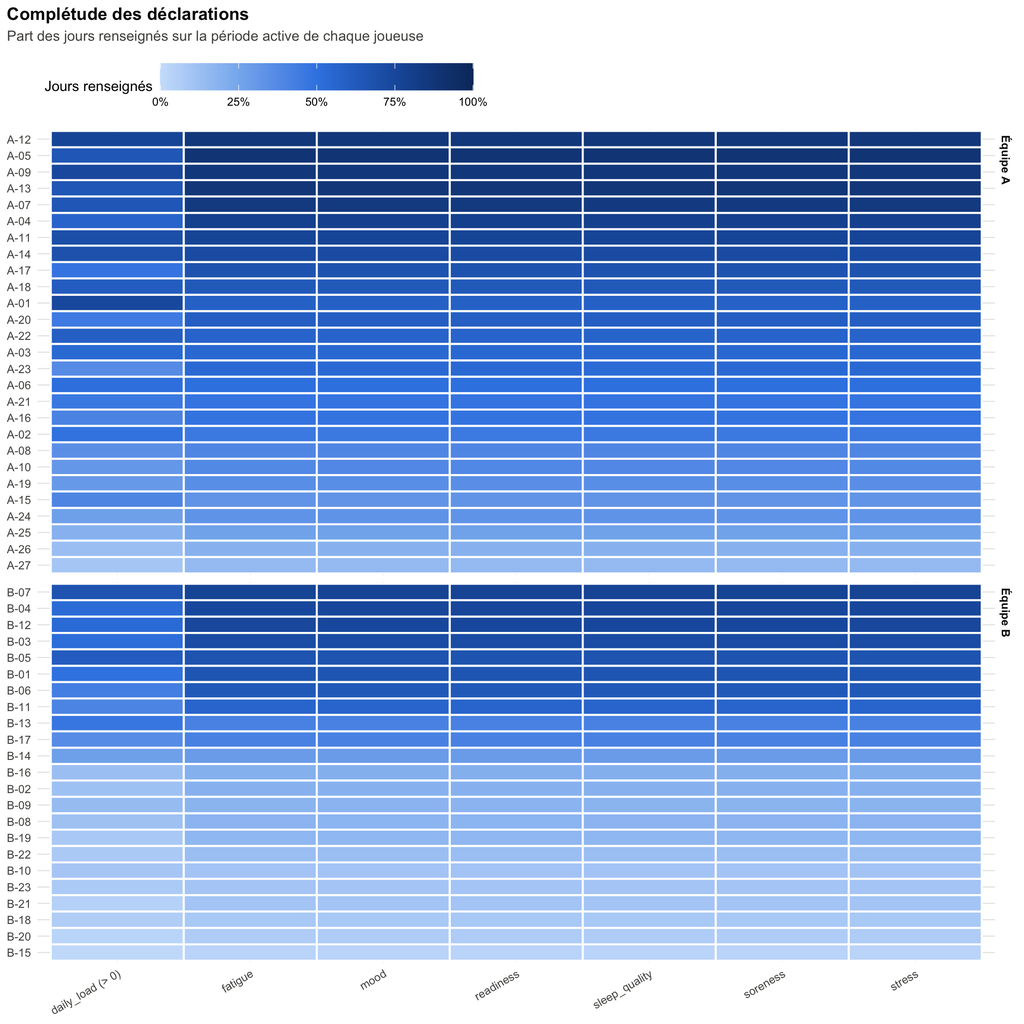

**Constat principal : dans SoccerMon, un jour sans déclaration de charge vaut 0.** Les fichiers couvrent tout le calendrier (y compris avant la reprise de la saison), et la charge n’y est jamais « manquante » : un repos et un questionnaire non rempli sont indiscernables. Conséquences pour l’analyse :

- la période de chaque joueuse est restreinte à sa **période active** (du premier au dernier jour avec une charge > 0) ;
- un jour est considéré comme **documenté** s’il a une charge > 0 ou un questionnaire wellness rempli ; les alertes ne sont émises que si au moins 70% des 28 derniers jours sont documentés ;
- **50 joueuse(s)** présentent au moins une plage de 14 jours consécutifs sans charge (absence, blessure, coupure ou non-déclaration : à confirmer avec le staff dans un contexte réel), détail dans `outputs/tables/qc_plages_sans_charge.csv` ;
- **1 valeur(s) suspecte(s)** (hors bornes plausibles ou non numériques) sont écartées du calcul et listées dans `outputs/tables/qc_valeurs_suspectes.csv`.

**Vérification de cohérence.** L’ACWR fourni dans SoccerMon et l’ACWR recalculé ici (moyennes glissantes 7 j / 28 j) sont comparés sur 21 490 jours-joueuses : corrélation 1.00, écart absolu moyen 0.00, 98% des jours à moins de 0,1 d’écart. Un écart important signale une différence de méthode (fenêtres, traitement des jours sans déclaration) à documenter avant d’utiliser l’une ou l’autre version.

## 2. Vue équipe

### État au dernier jour disponible

[output not shown]

### Charge hebdomadaire par joueuse

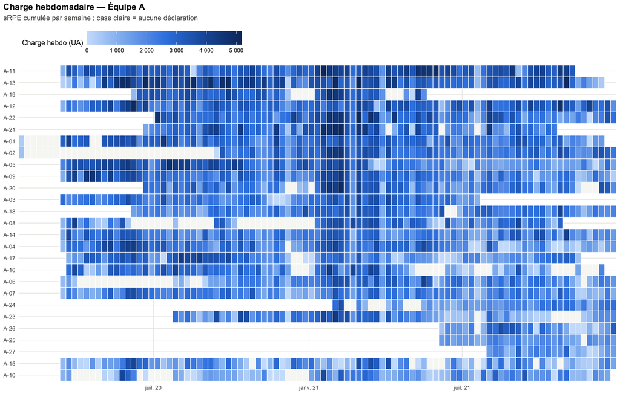

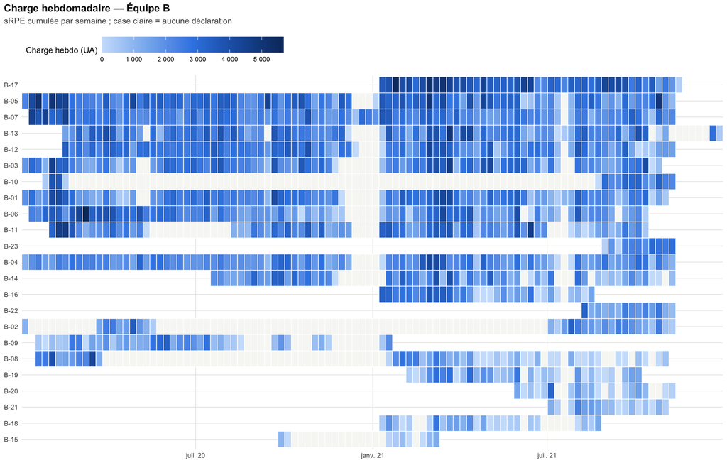

### Fréquence des points d’attention

Les alertes sont conçues pour rester **traitables par un staff** :

- **contexte équipe** : une joueuse n’est signalée que si son ACWR sort de la zone alors que la médiane de son équipe y reste, avec un écart d’au moins 0.2 (une coupure ou une reprise collective n’est pas un signal individuel) ;
- **persistance** : une alerte de charge n’apparaît qu’au 3<sup>e</sup> jour consécutif hors zone ;
- **épisodes** : des jours d’alerte consécutifs forment un seul épisode.

| Équipe | Jours-joueuses analysés | Épisodes / joueuse / an (médiane) | Hausse rapide (ACWR > 1,5) | Sous-charge (ACWR < 0,8) | Monotonie > 2 | Wellness < −1,5 σ |
| --- | --- | --- | --- | --- | --- | --- |
| Équipe A | 11717 | 16.4 | 0% | 3% | 3% | 2% |
| Équipe B | 5922 | 13.2 | 0% | 2% | 2% | 3% |

## 3. Vue joueuse

Exemple sur la joueuse la mieux renseignée de chaque équipe. Toute joueuse peut être affichée avec `fig_player_load(metrics, "<identifiant>")`.

### Joueuse A-12

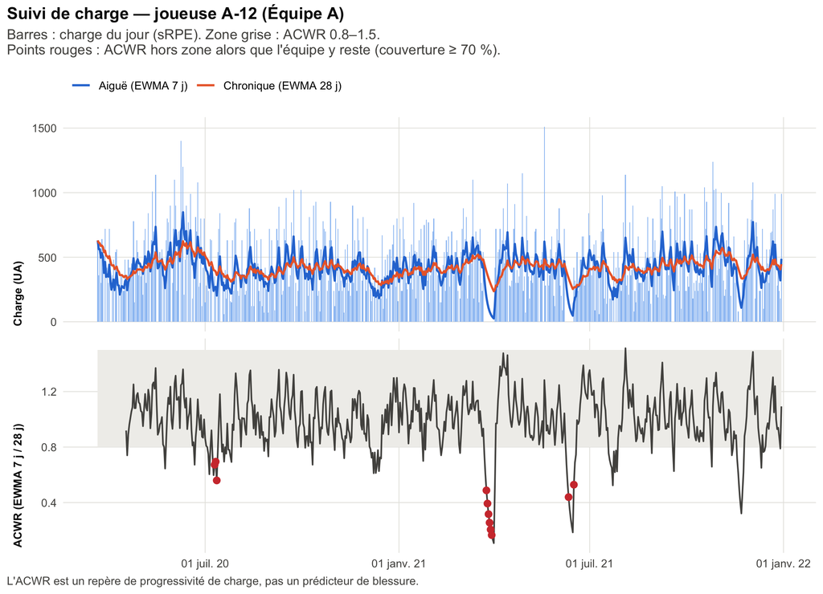

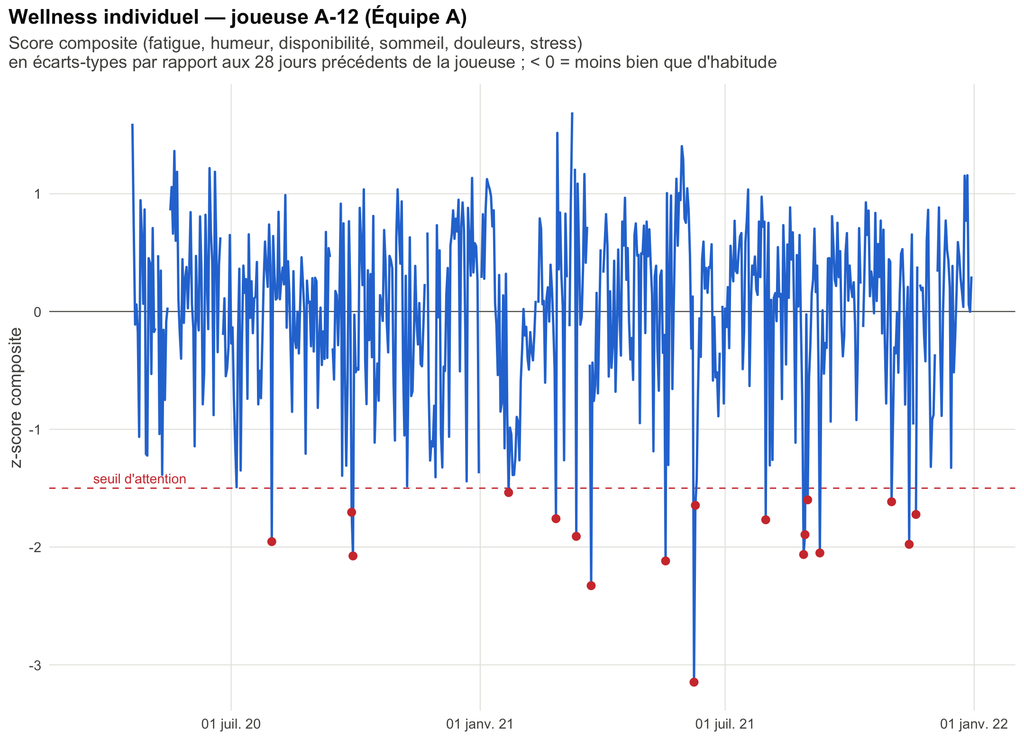

### Joueuse B-07

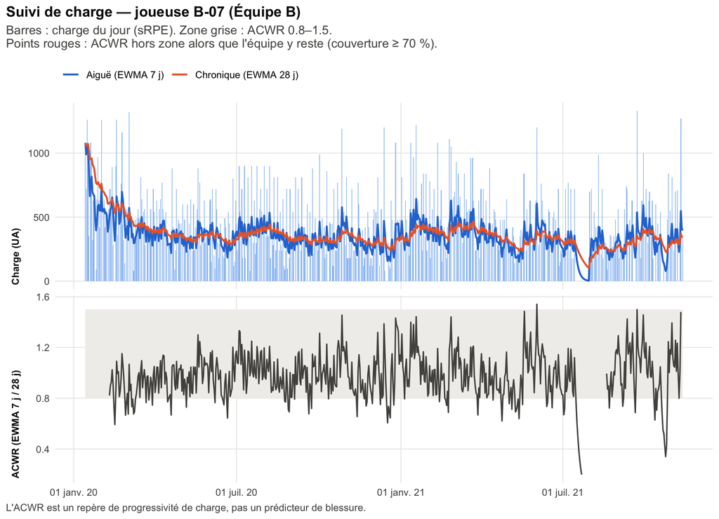

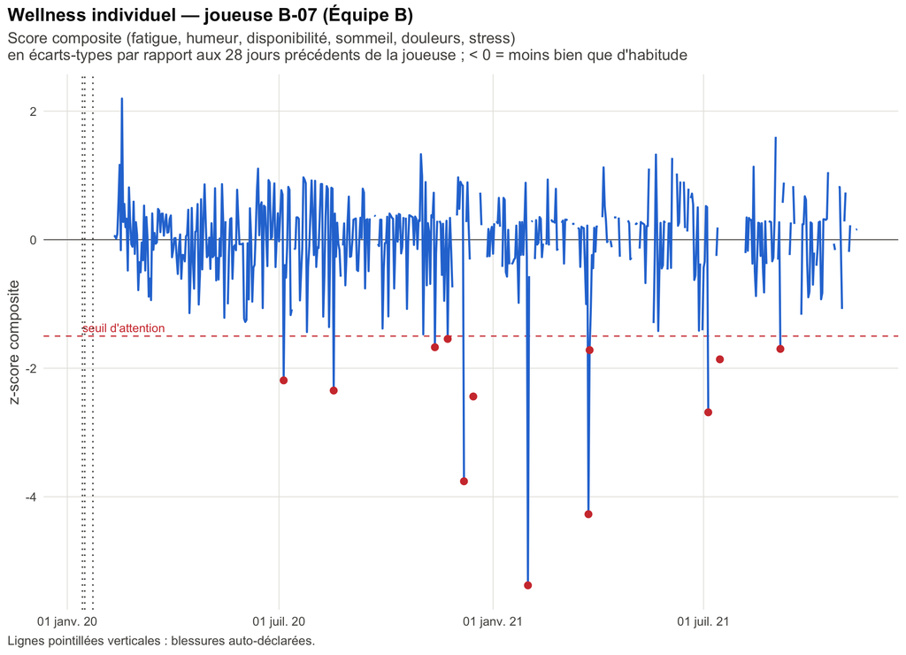

## 4. Charge externe (GPS)

Valeurs médianes par jour d’entraînement ou de match

| Contrôle qualité GPS | Valeur |
| --- | --- |
| Fichiers GPS | 10075 |
| Fichiers illisibles | 0 |
| Séances écartées (< 10 min ou < 300 m) | 86 |
| Jours-joueuses retenus | 9908 |
| Part médiane de signal perdu | 0.0% |
| Vitesse max médiane (km/h) | 23.6 |

| Équipe | Jours avec GPS | Distance (km) | Haute intensité > 19 km/h (m) | Sprint > 23 km/h (m) | Accélérations > 2 m/s² | Vitesse max (km/h) |
| --- | --- | --- | --- | --- | --- | --- |
| Équipe A | 4404 | 4.8 | 94 | 7 | 5 | 22.7 |
| Équipe B | 3095 | 4.7 | 98 | 9 | 6 | 22.9 |

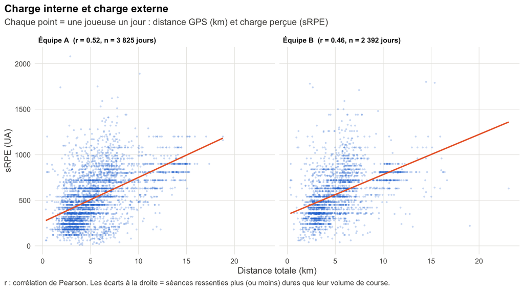

La charge perçue (sRPE) et la distance parcourue sont corrélées (r = 0.52 et 0.46 selon l’équipe) mais loin d’être identiques : à distance égale, une séance peut être ressentie très différemment. C’est l’intérêt de suivre les deux : la charge externe dit ce que la joueuse a fait, la charge interne comment elle l’a vécu.

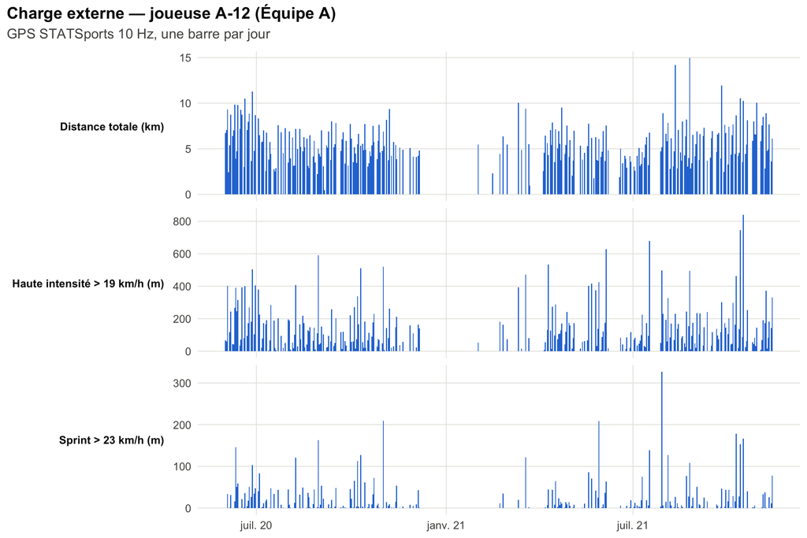

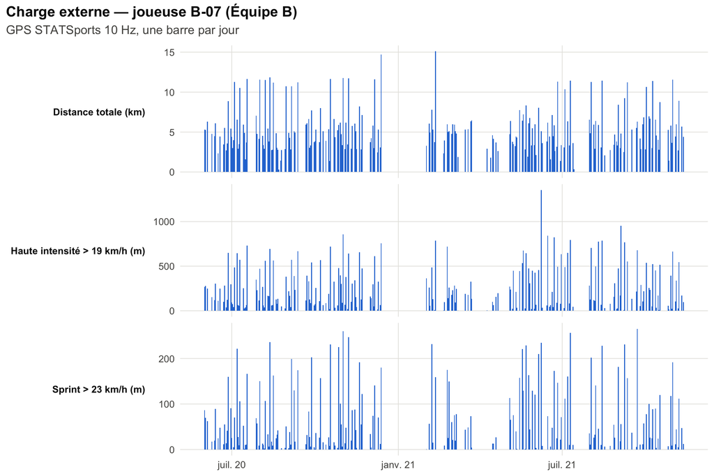

## 5. Ratio et valeurs absolues

Un ACWR décrit la relation entre charge récente et charge habituelle. Il ne dit pas à quel niveau d’exposition elle se produit : on le lit donc avec la charge aiguë et chronique en valeur absolue, et avec le **niveau de la base** (charge chronique rapportée à la normale de la joueuse, médiane de l’année précédente).

- Pour un ACWR sRPE entre 0,75 et 0,85 (1 807 jours-joueuses), la charge aiguë va de **189 à 379 UA/jour** (10<sup>e</sup>–90<sup>e</sup> percentiles).
- **71%** des jours d’alerte « hausse rapide » partent d’une base basse : surtout des reprises.
- **74%** des jours d’alerte « sous-charge » surviennent sur une base déjà basse : une sous-exposition durable.
- Charge externe : sur 5 071 jours-joueuses, l’ACWR sRPE et l’ACWR de haute intensité (> 19 km/h) sont corrélés à r = 0.33 ; dans **94%** des jours où l’ACWR de course rapide dépasse 1,5, l’ACWR sRPE reste sous ce seuil.

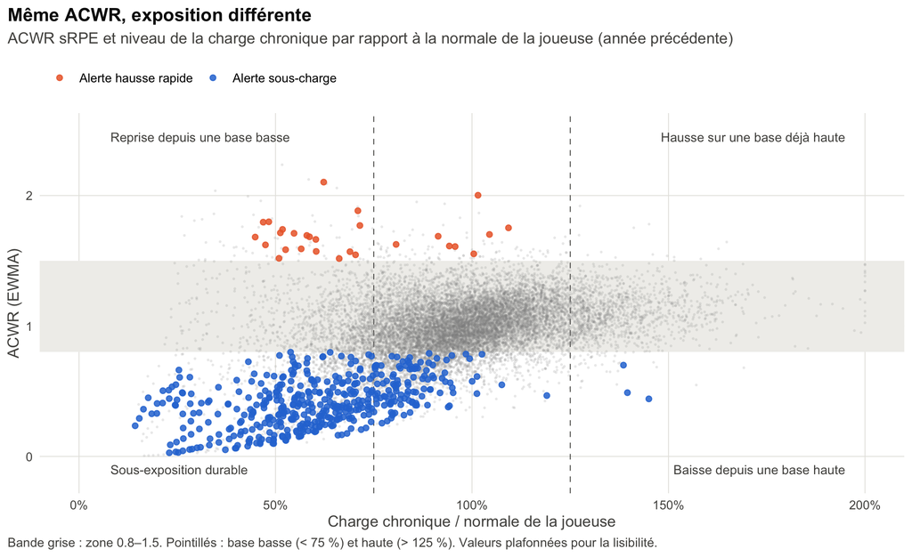

## 6. Retour au jeu

Absence = au moins 14 jours sans charge ni GPS ; chaque semaine après la reprise est comparée aux 28 jours qui précèdent l’absence (100 % = niveau d’avant).

- 34 absences individuelles (médiane 27 jours, dont 6 avec une blessure déclarée) et 40 collectives.
- Après une absence individuelle, charge perçue à **59%** de la référence en semaine 1, 76% en semaine 2, 114% en semaine 3.
- Après une coupure collective : 148% de la charge d’avant la coupure dès la semaine 1, vitesse max à 100%.
- Dans les 4 semaines après une reprise individuelle, l’ACWR est masqué **73%** des jours, alors que le ratio brut dépasse 1,5 sur 38% des jours.

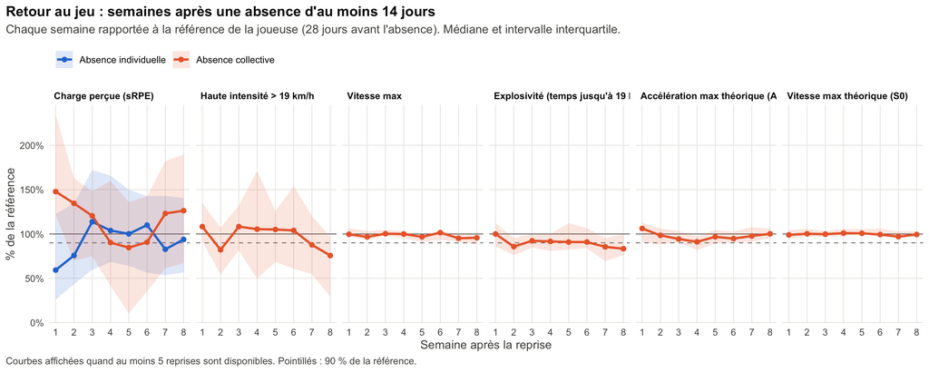

Profil accélération-vitesse en séance : 685 profils mensuels, A0 médian 7.52 m/s², S0 médian 8.02 m/s.

## 7. Seuils masculins ou féminins

Seuils féminins présentés par SkillCorner lors du webinaire public du 12/10/2026 (présentation transmise aux inscrits) : sprint > 23 km/h, accélération haute > 2,7 m/s², comparés aux seuils masculins (> 25 km/h, > 3 m/s²). Même vérification que SkillCorner, ici sur le GPS de SoccerMon (entraînements et matchs).

| Indicateur | Seuil masculin | Jours > 0 (H) | Médiane (H) | Seuil féminin | Jours > 0 (F) | Médiane (F) |
| --- | --- | --- | --- | --- | --- | --- |
| Distance de sprint (m) | > 25 km/h | 44% | 0 | > 23 km/h | 67% | 7.8 |
| Sprints d’au moins 1 s | > 25 km/h | 25% | 0 | > 23 km/h | 48% | 0.0 |
| Accélérations hautes | > 3 m/s² | 43% | 0 | > 2,7 m/s² | 65% | 1.0 |
| Décélérations hautes | < -3 m/s² | 75% | 2 | < -2,7 m/s² | 86% | 3.0 |

- Stabilité (corrélation ≥ 0,8 entre deux séries de jours) : plus de 40 jours avec le seuil masculin d’accélération, plus de 40 avec le seuil féminin ; sprint : plus de 40 contre plus de 40.
- Profils cachés (quart inférieur avec le seuil masculin, au-dessus de la médiane avec le seuil féminin) : 0 joueuses sur 46 pour les accélérations, 0 pour la distance de sprint.

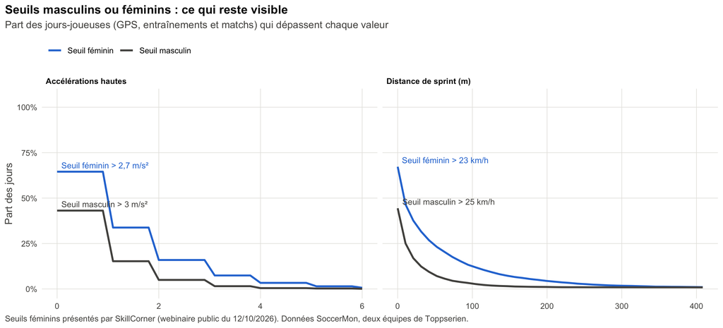

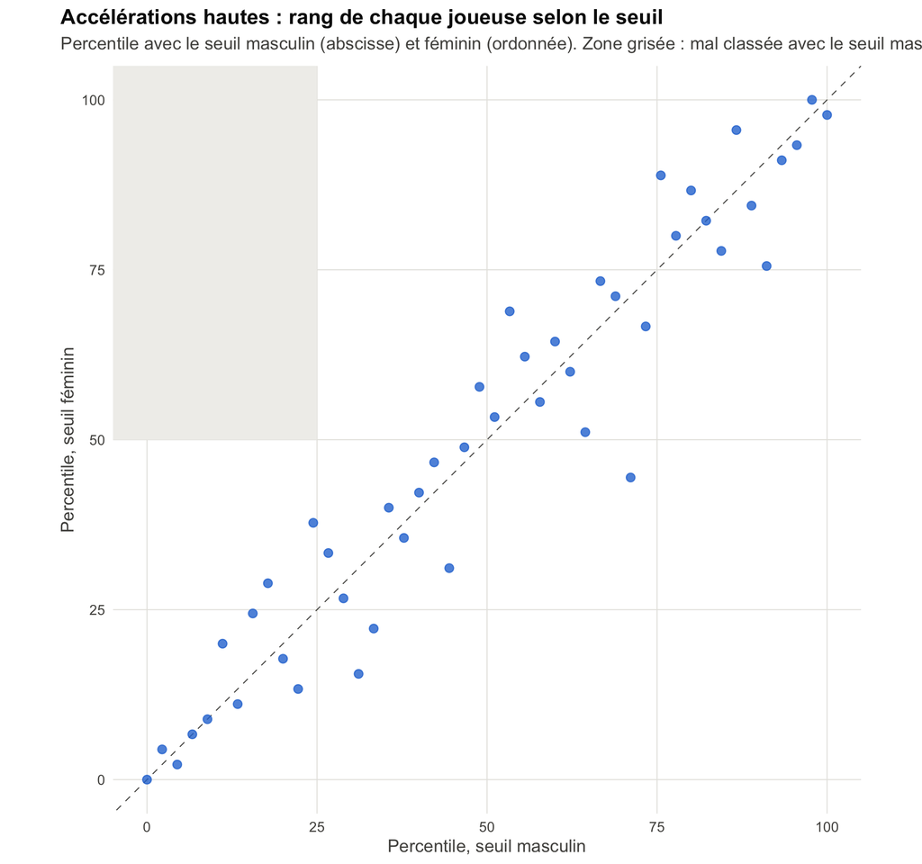

## 8. Piste de recherche appliquée

**Question.** Les jours qui précèdent une blessure déclarée se distinguent-ils par une évolution de la charge (ACWR) ou de l’état de forme déclaré (wellness) par rapport à la référence propre de chaque joueuse ?

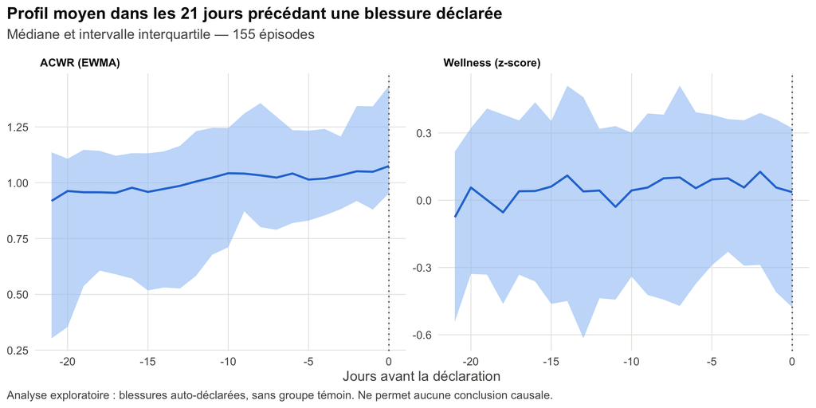

**Limites à garder en tête**

- Les blessures sont **auto-déclarées** (douleur mineure ou majeure), sans diagnostic médical : il s’agit de plaintes, pas forcément de blessures avec arrêt.
- Pas de groupe témoin dans ce graphique : un profil descriptif ne permet aucune conclusion causale. Étape suivante : comparer à des fenêtres de 21 jours sans blessure (modèle mixte avec effet aléatoire joueuse).
- L’ACWR est discuté dans la littérature (couplage aigu/chronique, instabilité des ratios) : il sert ici de repère de progressivité, pas d’outil de prédiction.
- Charge externe : distances et vitesses issues du GPS (10 Hz). La fréquence cardiaque enregistrée n’est pas exploitable (ceinture cardio absente lors de la plupart des séances).

## Méthode

| Indicateur | Calcul | Référence |
| --- | --- | --- |
| sRPE / charge du jour | RPE (1–10) × durée (min), cumulée par jour | Foster et al., 2001 |
| Charge aiguë / chronique | moyennes glissantes 7 j / 28 j ; EWMA 7 j / 28 j | Williams et al., 2017 |
| ACWR | aiguë / chronique (versions glissante et EWMA) | Gabbett, 2016 ; Impellizzeri et al., 2020 |
| Monotonie, strain | moyenne / écart-type sur 7 j ; charge hebdo × monotonie | Foster, 1998 |
| Wellness | z-score de chaque item vs 28 jours précédents de la joueuse, moyenne des items | approche individuelle |
| Niveau de la base | charge chronique / médiane de la charge chronique des 365 jours précédents | approche individuelle |
| ACWR GPS | EWMA 7 j / 28 j de la haute intensité (> 19 km/h) et du sprint (> 23 km/h), m/jour, couverture GPS ≥ 70 % | Williams et al., 2017 |
| Seuils féminins | course 13-19 km/h, haute intensité > 19, sprint > 23 km/h, accélération haute > 2,7 m/s² | SkillCorner, webinaire public du 12/10/2026 |

Code source et paramètres : `R/00_config.R` (tous les seuils y sont modifiables).